# HW week 11

w203: Statistics for Data Science

Da Qi Ren

## Regression analysis of YouTube dataset

You want to explain how much the quality of a video affects the number of views it receives on social media. **This is a causal question.**

You will use a dataset created by Cheng, Dale and Liu at Simon Fraser University. It includes observations about 9618 videos shared on YouTube. Please see [this link](http://netsg.cs.sfu.ca/youtubedata/) for details about how the data was collected.

You will use the following variables:

- views: the number of views by YouTube users.
- rate: the average rating given by users.
- length: the duration of the video in seconds.

You want to use the `rate` variable as a proxy for video quality. You also include `length` as a control variable. You estimate the following ols regression:

$$\text{views} = 789 + 2103 \text{ rate} + 3.00 \text{ length}$$
a. Name an omitted variable that you think could induce significant omitted variable bias. Argue whether the direction of bias is towards zero or away from zero.

ANSWER:

I answer this question in 2 ways:

(Method 1) Name an omitted variable “recommendation” representing if the video is recommended by the system, this data is not in the given data set. Therefore,

```
          $$\text{views} =   789 +  2103    \text{ rate} +      3.00 \text{ length} + \beta \times recommendation  $$
          $$\text{ rate} =\alpha0 + \alpha1 \times recommendation  $$
```

if
$$\beta2 > 0$$
and
$$\alpha1 > 0$$
then OMVB =
$$\beta2 \times \alpha1 > 0$$
. And if
$$\beta1 > 0$$
the OLS coefficient on views will scaled away from zero (more positive) gaining statistical significance.

(Method 2) Using the data in videos.csv file. Estimator Positively Biased Away from Zero In this case, we have an estimator that is biased in the positive direction. Since the coefficient that it is associated with is positive as well we would say it is biased away from zero. We break down the components of the omitted variable bias below.

```r
df<-read.csv('videos001.csv')

#df<-df %>%
#  select('rate', 'views', 'length', 'ratings')
df <- subset(df, select = c('rate', 'views', 'length', 'ratings'))
nrow(df)
```

```
## [1] 9617
```

```r
df <- na.omit(df)

k1 <- lm(df$views ~ df$rate + df$length)
summary(k1)
```

```
##
## Call:
## lm(formula = df$views ~ df$rate + df$length)
##
## Residuals:
##     Min      1Q  Median      3Q     Max
##  -26084  -10242   -6542    -828 1796480
##
## Coefficients:
##             Estimate Std. Error t value Pr(>|t|)
## (Intercept)  789.033    906.424   0.870    0.384
## df$rate     2103.880    213.447   9.857   <2e-16 ***
## df$length      2.996      1.599   1.874    0.061 .
## ---
## Signif. codes:  0 '***' 0.001 '**' 0.01 '*' 0.05 '.' 0.1 ' ' 1
##
## Residual standard error: 36960 on 9606 degrees of freedom
## Multiple R-squared:  0.01123,    Adjusted R-squared:  0.01103
## F-statistic: 54.57 on 2 and 9606 DF,  p-value: < 2.2e-16
```

```r
sprintf("a1 is %d", (a1 <- sign(cor(df$views,df$ratings))))
```

```
## [1] "a1 is 1"
```

```r
sprintf("a2 is %d", (a2 <- sign(cor(df$rate ,df$ratings))))
```

```
## [1] "a2 is 1"
```

```r
sprintf("a2 is %d", (a2 <- sign(cor(df$length ,df$ratings))))
```

```
## [1] "a2 is 1"
```

```r
sprintf("Estimation are all positive")
```

```
## [1] "Estimation are all positive"
```

```r
k1 <- lm(df$views ~ df$ratings)
k2 <- lm(df$rate ~ df$ratings)
k3 <- lm(df$length ~ df$ratings)
k7 <- lm(df$views ~ df$rate + df$length + df$ratings)

stargazer(k1, k2, k3, k7,  type = "text")
```

```
##
## ===============================================================================================================================
##                                                                 Dependent variable:
##                     -----------------------------------------------------------------------------------------------------------
##                                views                       rate                     length                     views
##                                 (1)                         (2)                      (3)                        (4)
## -------------------------------------------------------------------------------------------------------------------------------
## rate                                                                                                         345.894**
##                                                                                                              (150.084)
##
## length                                                                                                       -4.332***
##                                                                                                               (1.119)
##
## ratings                      356.622***                  0.003***                  0.267***                 356.725***
##                               (3.517)                    (0.0002)                  (0.032)                    (3.551)
##
## Constant                    1,979.117***                 3.681***                 221.466***               1,665.344***
##                              (273.377)                    (0.019)                  (2.518)                   (633.058)
##
## -------------------------------------------------------------------------------------------------------------------------------
## Observations                   9,609                       9,609                    9,609                      9,609
## R2                             0.517                       0.016                    0.007                      0.518
## Adjusted R2                    0.517                       0.016                    0.007                      0.518
## Residual Std. Error    25,834.140 (df = 9607)        1.774 (df = 9607)       237.959 (df = 9607)      25,812.570 (df = 9605)
## F Statistic         10,280.550*** (df = 1; 9607) 159.788*** (df = 1; 9607) 68.125*** (df = 1; 9607) 3,438.597*** (df = 3; 9605)
## ===============================================================================================================================
## Note:                                                                                               *p<0.1; **p<0.05; ***p<0.01
```

Estimator Positively Biased Away from Zero In this case, we have an estimator that is biased in the positive direction. Since the coefficient that it is associated with is positive as well we would say it is biased away from zero. We break down the components of the omitted variable bias below.

[output not shown]

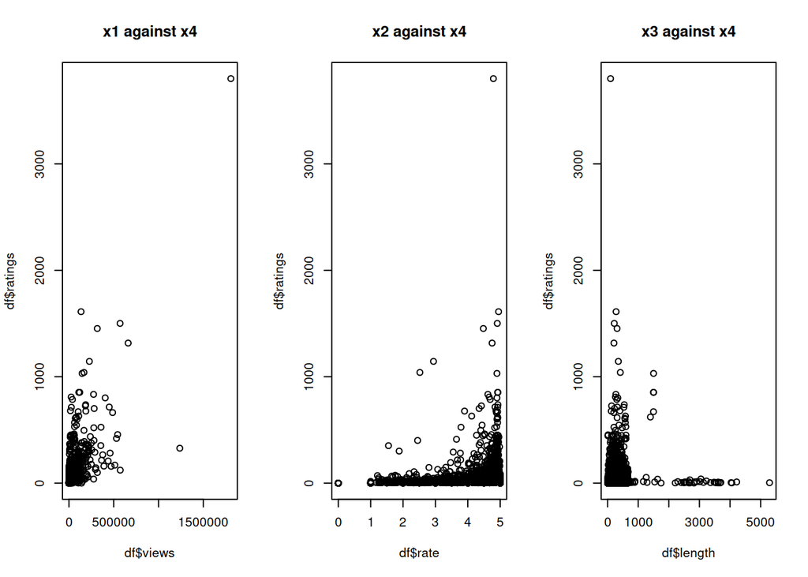

```r
par(mfrow=c(1,3))
plot(df$views,df$ratings, main="x1 against x4")
plot(df$rate,df$ratings, main="x2 against x4")
plot(df$length,df$ratings, main="x3 against x4")
```

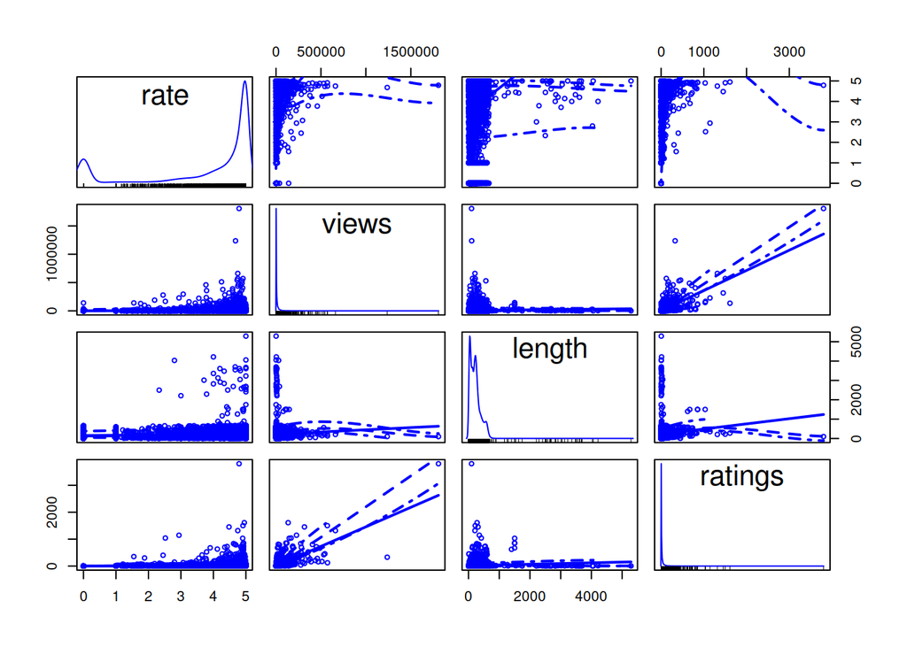

```r
car::scatterplotMatrix(df[, c('rate', 'views', 'length', 'ratings')])
```

```r
k6 <- lm(df$ratings ~ df$length)
summary(k6)
```

```
##
## Call:
## lm(formula = df$ratings ~ df$length)
##
## Residuals:
##    Min     1Q Median     3Q    Max
## -150.0  -17.8  -14.3   -5.2 3783.7
##
## Coefficients:
##             Estimate Std. Error t value Pr(>|t|)
## (Intercept) 14.68067    1.05106  13.967   <2e-16 ***
## df$length    0.02633    0.00319   8.254   <2e-16 ***
## ---
## Signif. codes:  0 '***' 0.001 '**' 0.01 '*' 0.05 '.' 0.1 ' ' 1
##
## Residual standard error: 74.67 on 9607 degrees of freedom
## Multiple R-squared:  0.007041,   Adjusted R-squared:  0.006938
## F-statistic: 68.12 on 1 and 9607 DF,  p-value: < 2.2e-16
```

```r
sprintf("a1 is %d", (a1    <- sign(cor(df$views,df$ratings))))
```

```
## [1] "a1 is 1"
```

```r
sprintf("a2 is %d", (a2    <- sign(cor(df$rating, df$length))))
```

```
## [1] "a2 is 1"
```

```r
sprintf("a3 is %d", (a3    <- sign(cor(df$ratings, df$rate))))
```

```
## [1] "a3 is 1"
```

```r
sprintf("adir(estimate) is %d",(adir <- a1*a2*a3))
```

```
## [1] "adir(estimate) is 1"
```

```r
#stargazer(mod1, mod2, type = "text")
```

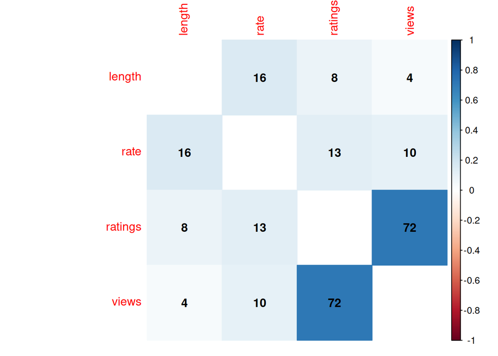

```r
## corrplot takes a correlation matrix as an arument
  # needs the corrplot package
corrplot::corrplot(cor(df),method = "color",order="AOE",
                   diag=FALSE, addCoef.col = "black", addCoefasPercent = TRUE)
```

```r
cor(df$ratings, df$rate)
```

```
## [1] 0.1279075
```

```r
cor(df$views, df$ratings)
```

```
## [1] 0.7189812
```

```r
cor(df$views, df$rate)
```

```
## [1] 0.1042721
```

```r
cor(df$views, df$length)
```

```
## [1] 0.03512544
```

```r
cor(df$ratings, df$length)
```

```
## [1] 0.08391187
```

```r
cor(df$rate, df$length)
```

```
## [1] 0.1568035
```

Discuss of Omitted Variables

2. Provide a story for why there might be a reverse causal pathway (from the number of views to the average rating). Argue whether the direction of bias is towards zero or away from zero.

```r
c3 <- lm(df$ratings ~ df$views)
summary(c3)
```

```
##
## Call:
## lm(formula = df$ratings ~ df$views)
##
## Residuals:
##      Min       1Q   Median       3Q      Max
## -1472.88    -7.44    -5.76    -0.73  1408.03
##
## Coefficients:
##              Estimate Std. Error t value Pr(>|t|)
## (Intercept) 7.1103069  0.5478719   12.98   <2e-16 ***
## df$views    0.0014495  0.0000143  101.39   <2e-16 ***
## ---
## Signif. codes:  0 '***' 0.001 '**' 0.01 '*' 0.05 '.' 0.1 ' ' 1
##
## Residual standard error: 52.08 on 9607 degrees of freedom
## Multiple R-squared:  0.5169, Adjusted R-squared:  0.5169
## F-statistic: 1.028e+04 on 1 and 9607 DF,  p-value: < 2.2e-16
```

```r
stargazer(c3, type = 'text' )
```

```
##
## ================================================
##                         Dependent variable:
##                     ----------------------------
##                               ratings
## ------------------------------------------------
## views                         0.001***
##                              (0.00001)
##
## Constant                      7.110***
##                               (0.548)
##
## ------------------------------------------------
## Observations                   9,609
## R2                             0.517
## Adjusted R2                    0.517
## Residual Std. Error      52.084 (df = 9607)
## F Statistic         10,280.550*** (df = 1; 9607)
## ================================================
## Note:                *p<0.1; **p<0.05; ***p<0.01
```

```r
sprintf("a1 is %d", (a1 <- sign(cor(df$views,df$rate))))
```

```
## [1] "a1 is 1"
```

3. You are considering adding a new variable, `rating`, which represents the total number of ratings. Explain how this would affect your measurement goal.

```r
c9 <-lm(df$views ~ df$rate + df$length)
c10 <-lm(df$views ~ df$rate + df$length + df$ratings)

#summary(c9, c10)
anova(c9)
```

```
## Analysis of Variance Table
##
## Response: df$views
##             Df     Sum Sq    Mean Sq F value  Pr(>F)
## df$rate      1 1.4431e+11 1.4431e+11 105.629 < 2e-16 ***
## df$length    1 4.7968e+09 4.7968e+09   3.511 0.06099 .
## Residuals 9606 1.3124e+13 1.3662e+09
## ---
## Signif. codes:  0 '***' 0.001 '**' 0.01 '*' 0.05 '.' 0.1 ' ' 1
```

```r
anova(c10)
```

```
## Analysis of Variance Table
##
## Response: df$views
##              Df     Sum Sq    Mean Sq    F value    Pr(>F)
## df$rate       1 1.4431e+11 1.4431e+11   216.5921 < 2.2e-16 ***
## df$length     1 4.7968e+09 4.7968e+09     7.1993  0.007306 **
## df$ratings    1 6.7242e+12 6.7242e+12 10091.9994 < 2.2e-16 ***
## Residuals  9605 6.3997e+12 6.6629e+08
## ---
## Signif. codes:  0 '***' 0.001 '**' 0.01 '*' 0.05 '.' 0.1 ' ' 1
```

```r
anova(c9, c10)
```

```
## Analysis of Variance Table
##
## Model 1: df$views ~ df$rate + df$length
## Model 2: df$views ~ df$rate + df$length + df$ratings
##   Res.Df        RSS Df  Sum of Sq     F    Pr(>F)
## 1   9606 1.3124e+13
## 2   9605 6.3997e+12  1 6.7242e+12 10092 < 2.2e-16 ***
## ---
## Signif. codes:  0 '***' 0.001 '**' 0.01 '*' 0.05 '.' 0.1 ' ' 1
```

When you use anova(lm.1,lm.2,test=“Chisq”), it performs the Chi-square test to compare lm.1 and lm.2 (i.e. it tests whether reduction in the residual sum of squares are statistically significant or not). Note that this makes sense only if lm.1 and lm.2 are nested models.